# Emoxicon Paper Analysis

Tara L. Valladares

4/03/2020

## Prepare Trolls Data

This data was saved into the emoxicon package. It was not run here for speed. Cleaning included:

- Only english-language tweets
- Only right/left trolls
- Remove duplicate tweets
- Remove manual reposts (i.e., those labeled with “rt”)
- Remove links
- Remove empty tweets (e.g., used to have a link, was just an image, etc.)

```r
## code to prepare `trolls` dataset

### not run ###
# trolls_raw <- vector("list", ndoc)
# for(i in 1:ndoc){
#   trolls_raw[[i]]<- read.csv(paste0("../russian-troll-tweets-master/IRAhandle_tweets_", i,".csv"),
#               stringsAsFactors = FALSE)
# }
# trolls<-vector("list",ndoc)
# for(i in 1:ndoc){
#   trolls[[i]]<- trolls_raw[[i]][which(trolls_raw[[i]]$language == "English"),]
# }
#
# # Remove retweets
# trolls.clean <- lapply(trolls,function(x){
#   x<-x[which(x$retweet == 0),]
# } )
#
# # clean data
# trolls.clean <- lapply(trolls.clean, function(y){
#   content<- y$content
#   content<- stringi::stri_trans_general(content, "latin-ascii")
#   content<- gsub("&amp", "and", content)
#   content<- gsub("http[^[:space:]]*", "", content) # remove links
#   content<- tolower(content)
#   content<- gsub("^rt.*", "", content) # remove reposts
#
#   results<- cbind(content, y[,c("author", "publish_date", "followers", "updates","account_type")])
#   results<- results[which(results$account_type=="Left"|
#                             results$account_type=="Right"),]
#   results<- subset(results, content !="") #remove empty tweets
# })
#
# trolls<-do.call(rbind, trolls.clean)
# trolls$content<- as.character(trolls$content)
```

## Run Emoxicon

These terms were excluded as they are hypothesized not to have the same emotional valence between groups. If I kept them in, they would inflate those emotional categories.

```r
# Load data from Emoxicon package
data(trolls)

# Create vector of unique author names w/ more than 30 tweets, for later
author.small <- trolls[c("author", "account_type")]
author.small<- author.small[author.small$author %in% unique(trolls$author)[table(trolls$author) > 29],]
author.small <- unique(author.small)

# Run Emoxicon
exclude <-c("hilary", "hillary", "russia", "russian",
            "trump", "bernie", "clinton", "rt")
trolls_scored <- emoxicon(text=trolls$content, lexicon = "emotions",
                          exclude = exclude)
```

```
## Removing tokens in 'exclude' from the lexicon
```

```r
# Run Rasch models

trolls_models <- rasch(scores= trolls_scored, groups = trolls$author, return_models = TRUE)
```

```
## Mean split performed to dichotomize data.
```

```
## Rasch models were not run for groups with less than 30 observations
```

## Fit

```r
# Fit
summary(trolls_models$full_model)
```

```
##
## Results of RM estimation:
##
## Call:  eRm::RM(X = scores_all)
##
## Conditional log-likelihood: -1368470
## Number of iterations: 7
## Number of parameters: 7
##
## Item (Category) Difficulty Parameters (eta): with 0.95 CI:
##           Estimate Std. Error lower CI upper CI
## AMUSED      -0.112      0.003   -0.118   -0.106
## ANGRY        0.144      0.003    0.138    0.151
## ANNOYED     -0.296      0.003   -0.302   -0.290
## DONT_CARE   -0.827      0.003   -0.833   -0.821
## HAPPY        1.132      0.004    1.124    1.139
## INSPIRED    -0.151      0.003   -0.157   -0.145
## SAD          0.133      0.003    0.127    0.139
##
## Item Easiness Parameters (beta) with 0.95 CI:
##                Estimate Std. Error lower CI upper CI
## beta AFRAID       0.024      0.003    0.018    0.030
## beta AMUSED       0.112      0.003    0.106    0.118
## beta ANGRY       -0.144      0.003   -0.151   -0.138
## beta ANNOYED      0.296      0.003    0.290    0.302
## beta DONT_CARE    0.827      0.003    0.821    0.833
## beta HAPPY       -1.132      0.004   -1.139   -1.124
## beta INSPIRED     0.151      0.003    0.145    0.157
## beta SAD         -0.133      0.003   -0.139   -0.127
```

```r
pparameters <- eRm::person.parameter(trolls_models$full_model)

pfit <- eRm::personfit(pparameters)
ifit <- eRm::itemfit(pparameters)
pmis <- eRm::PersonMisfit(pparameters)

ifit
```

```
##
## Itemfit Statistics:
##              Chisq     df p-value Outfit MSQ Infit MSQ Outfit t Infit t Discrim
## AFRAID    398583.0 400093   0.954      0.996     0.997   -2.141  -2.393     NaN
## AMUSED    402732.4 400093   0.002      1.007     1.010    3.944   8.321     NaN
## ANGRY     378762.5 400093   1.000      0.947     0.968  -27.347 -23.592     NaN
## ANNOYED   401184.6 400093   0.111      1.003     1.003    1.807   2.830     NaN
## DONT_CARE 388369.5 400093   1.000      0.971     0.977  -20.158 -20.123     NaN
## HAPPY     356863.8 400093   1.000      0.892     0.917  -28.827 -32.616     NaN
## INSPIRED  418707.2 400093   0.000      1.047     1.034   28.124  28.226     NaN
## SAD       386314.0 400093   1.000      0.966     0.975  -17.690 -18.386     NaN
```

```r
pmis
```

```
##
## Percentage of Misfitting Persons: 0.9065 %
```

Low levels of misfit across persons. It does not seem to be influenced by raw score.

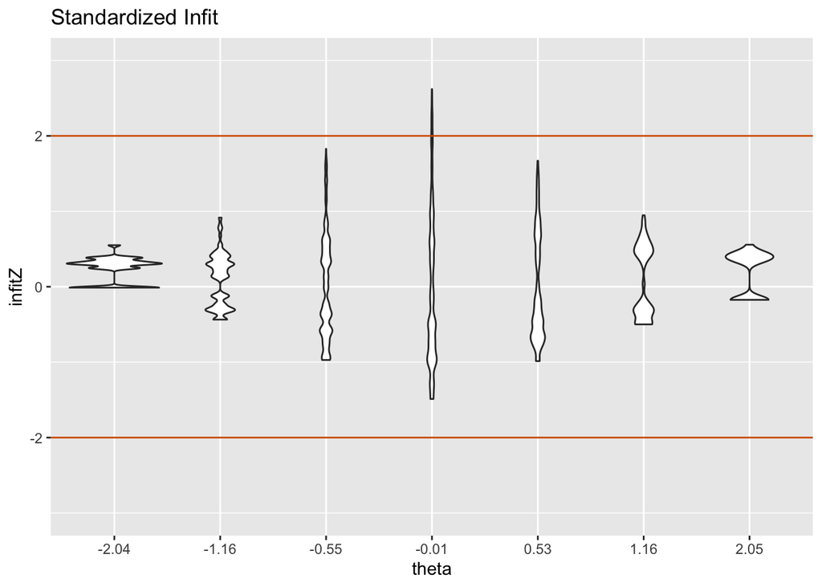

```r
# infit/outfit plots by theta-----
plotdat <- data.frame(theta = as.factor(pparameters$thetapar[[1]]),
                      infitZ =pfit$p.infitZ,
                      outfitZ =pfit$p.outfitZ,
                      se = pparameters$se.theta$NAgroup1)
levels(plotdat$theta) <- round(as.numeric(levels(plotdat$theta)),2)

ggplot(data = plotdat, aes(x = theta, y=infitZ)) +
  # geom_jitter(aes(x = theta, y=infitZ),height = .1, width = .1)
  geom_violin() + geom_hline(yintercept = c(2,-2), col="#D55E00") +
  ylim(-3,3) + ggtitle("Standardized Infit")
```

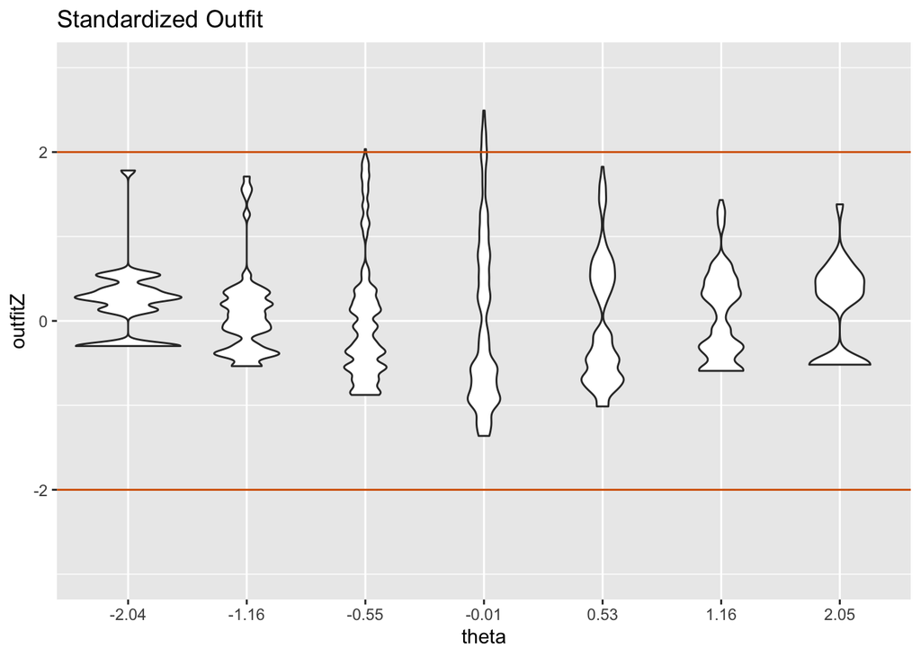

```r
ggplot(data = plotdat, aes(x = theta, y=outfitZ)) +
  # geom_jitter(aes(x = theta, y=infitZ),height = .1, width = .1)
  geom_violin() + geom_hline(yintercept = c(2,-2), col="#D55E00") +
  ylim(-3,3) + ggtitle("Standardized Outfit")
```

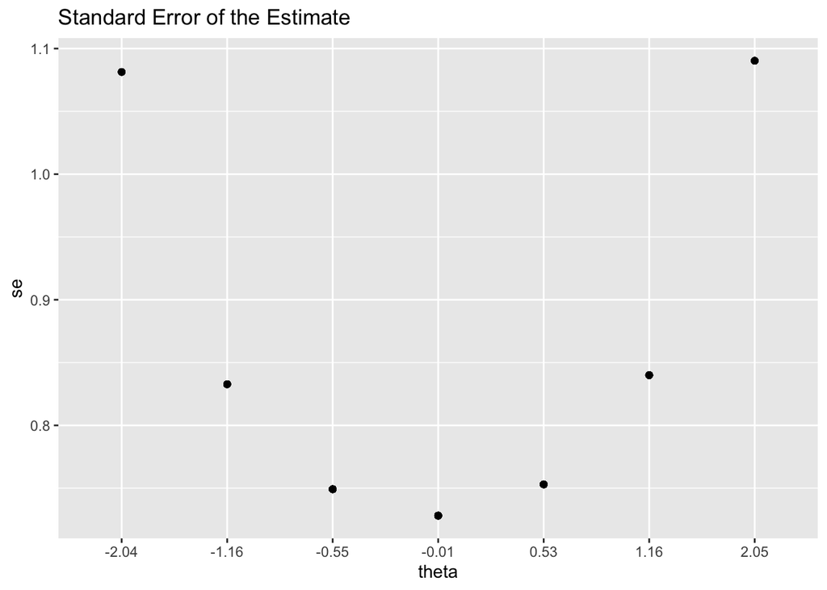

```r
ggplot(data = unique(plotdat), aes(x = theta, y=se)) +
  # geom_jitter(aes(x = theta, y=infitZ),height = .1, width = .1)
  geom_point() + ggtitle("Standard Error of the Estimate")
```

## DIF, overall model

Person-item map is okay. Lots of people towards the bottom of the distribution.

Doesn’t seem to be a large amount of DIF between low and high scores.

There seems to be DIF between left and right trolls. Specifically, INSPIRRED is harder for Right trolls. ANNOYED, AMUSED, AFRAID are harder for Left trolls.

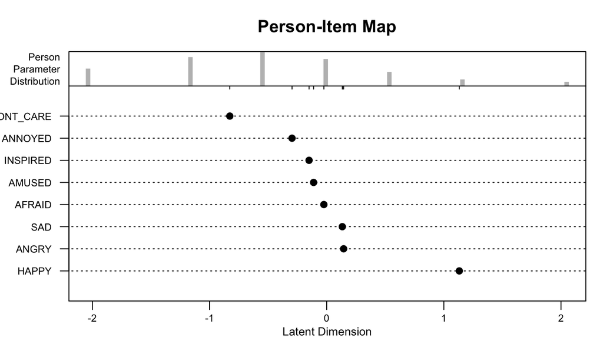

```r
# fit plots -----
# person item map
plotPImap(trolls_models$full_model, sorted = TRUE)
```

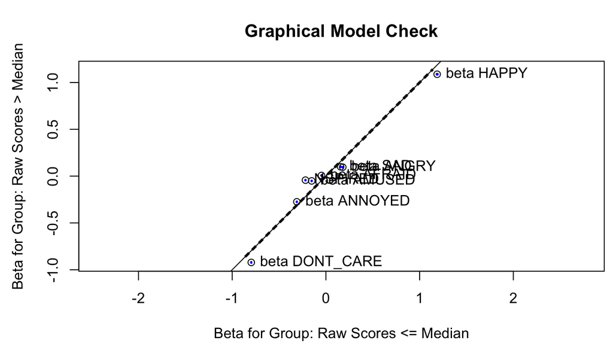

```r
# check if high and low scores are the same
lrres.rasch <- LRtest(trolls_models$full_model, splitcr = "median")
plotGOF(lrres.rasch, tlab = "item",
        conf = list(ia = FALSE, col = "blue", lty = "dotted"),
        smooline= list(gamma = .95, col = "black", lty = "dashed"))
```

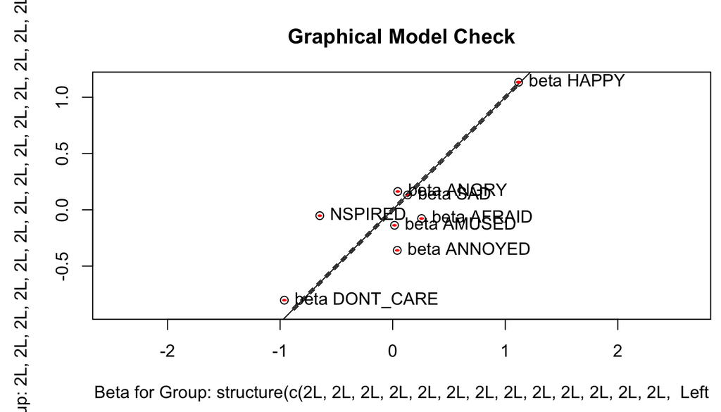

```r
# check if left and right trolls are the same
lrres <- LRtest(trolls_models$full_model, splitcr = trolls$account_type)
plotGOF(lrres, tlab = "item",
        conf = list(ia = FALSE, col = "red", lty = "dotted"),
        smooline = list(gamma = .95, col = "black", lty = "dashed"))
```

## ICCs

ICCs look great. Always monotonically increasing.

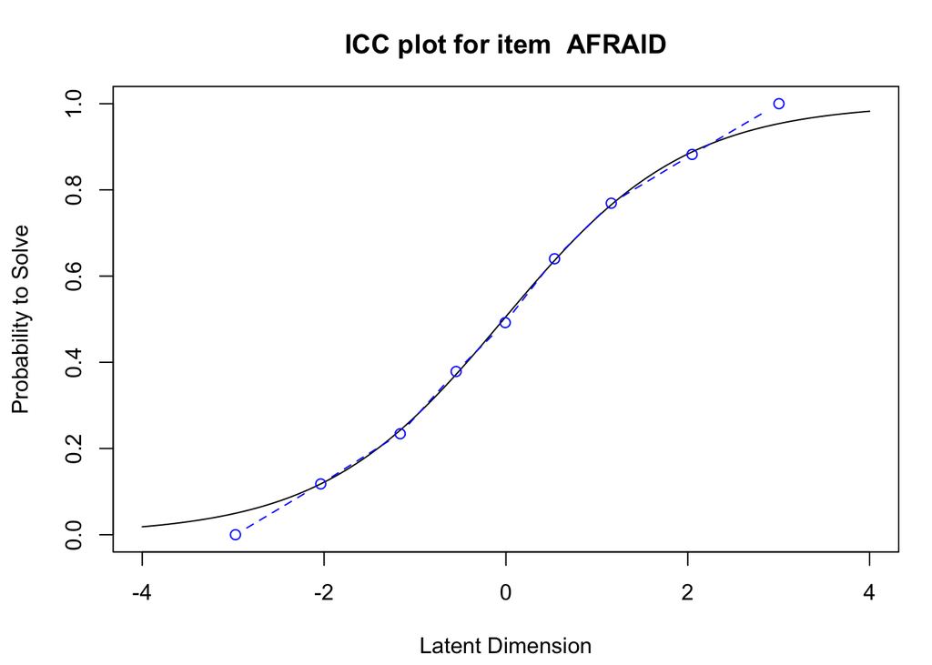

```r
# Look at empiracal plots, ICCs

plotICC(trolls_models$full_model,1, empICC = list("raw", type="b",col = "blue", lty = 2))
```

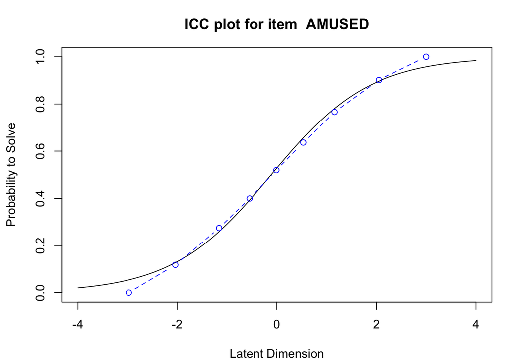

```r
plotICC(trolls_models$full_model,2, empICC = list("raw", type="b",col = "blue", lty = 2))
```

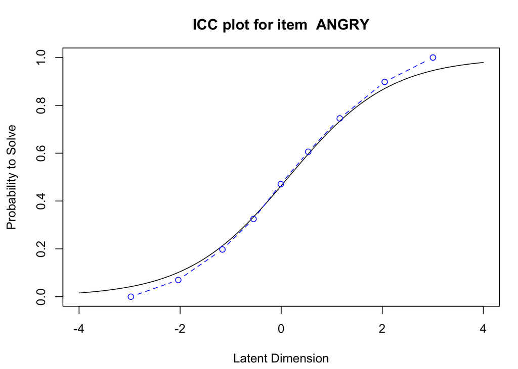

```r
plotICC(trolls_models$full_model,3, empICC = list("raw", type="b",col = "blue", lty = 2))
```

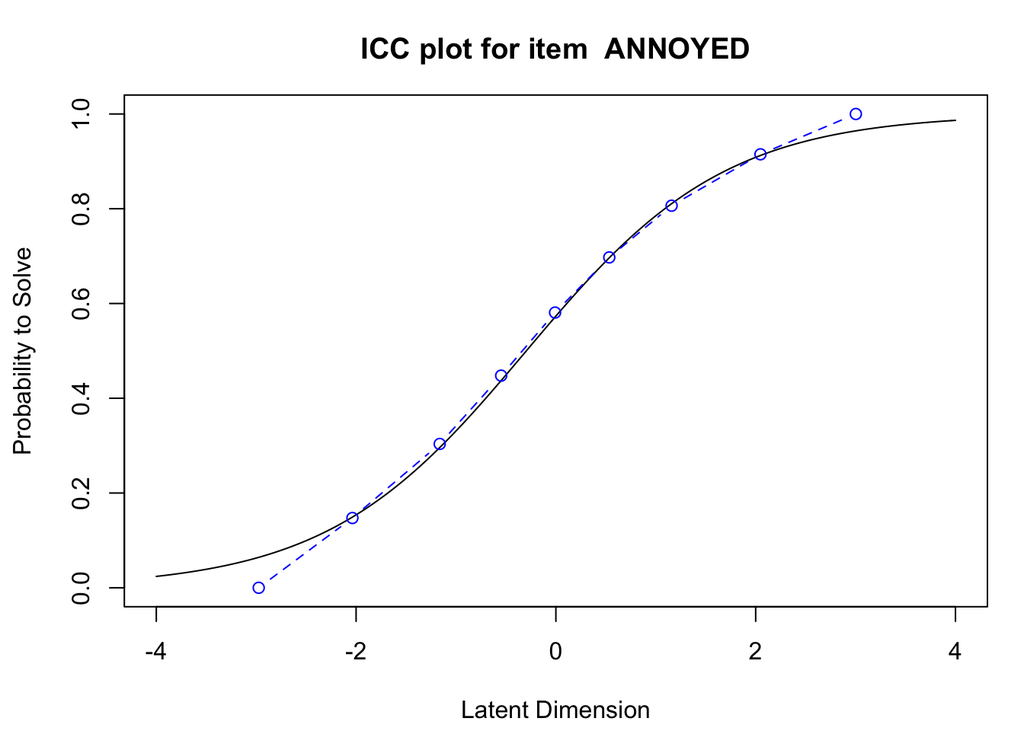

```r
plotICC(trolls_models$full_model,4, empICC = list("raw", type="b",col = "blue", lty = 2))
```

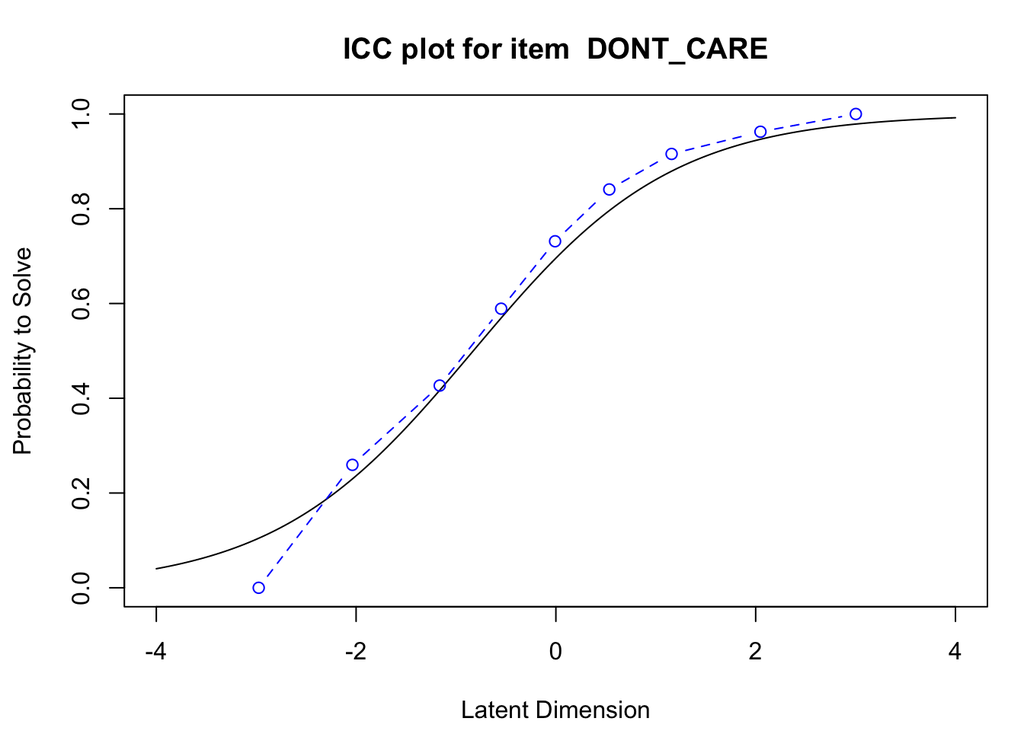

```r
plotICC(trolls_models$full_model,5, empICC = list("raw", type="b",col = "blue", lty = 2))
```

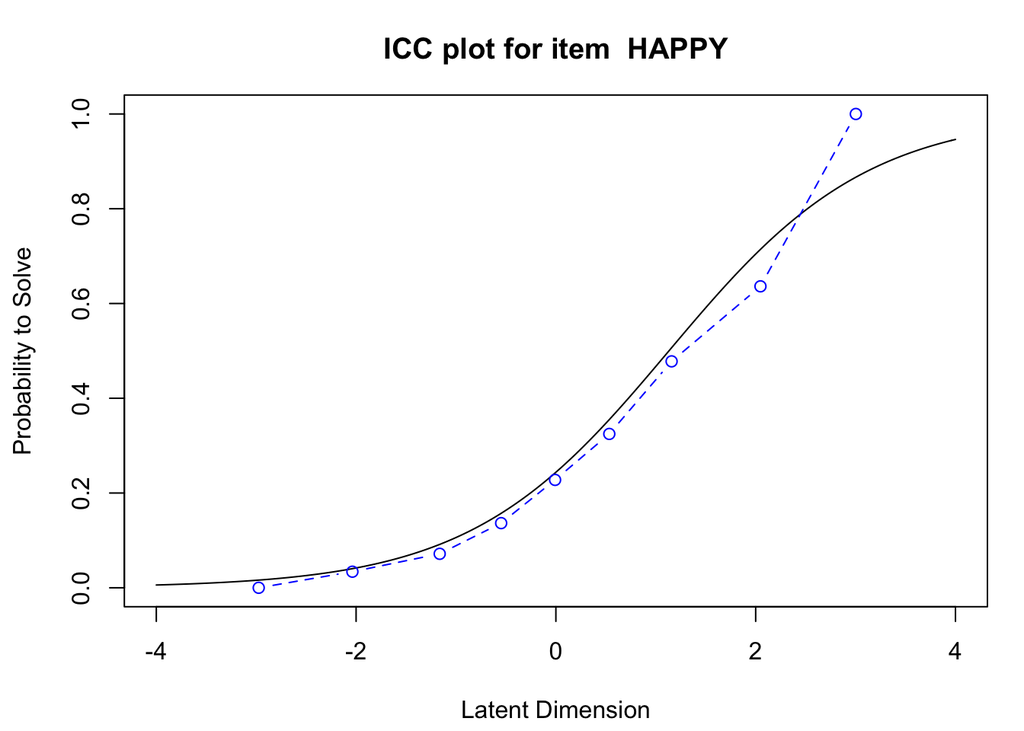

```r
plotICC(trolls_models$full_model,6, empICC = list("raw", type="b",col = "blue", lty = 2))
```

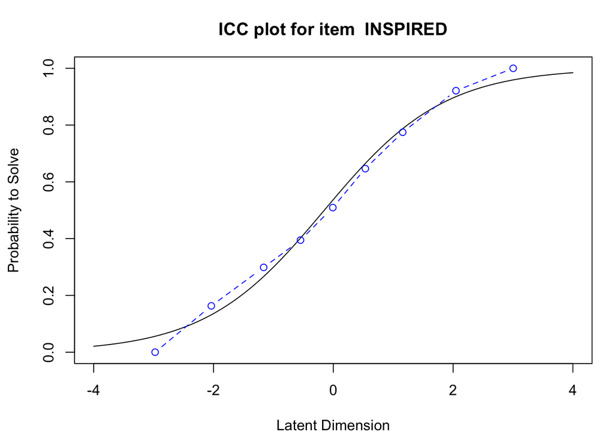

```r
plotICC(trolls_models$full_model,7, empICC = list("raw", type="b",col = "blue", lty = 2))
```

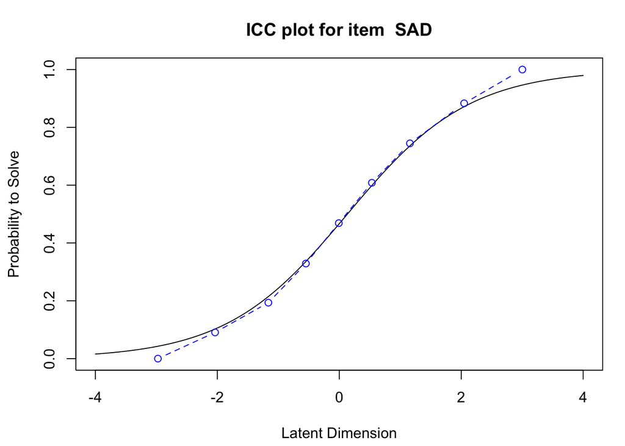

```r
plotICC(trolls_models$full_model,8, empICC = list("raw", type="b",col = "blue", lty = 2))
```

## Empirical plots

Here we are plotting reduced total raw scores against the proportion of people who endorsed the item. These are very flat and pretty similar. This matches the item difficulties - they for the most part all quite similar. Worrisome? Not sure.

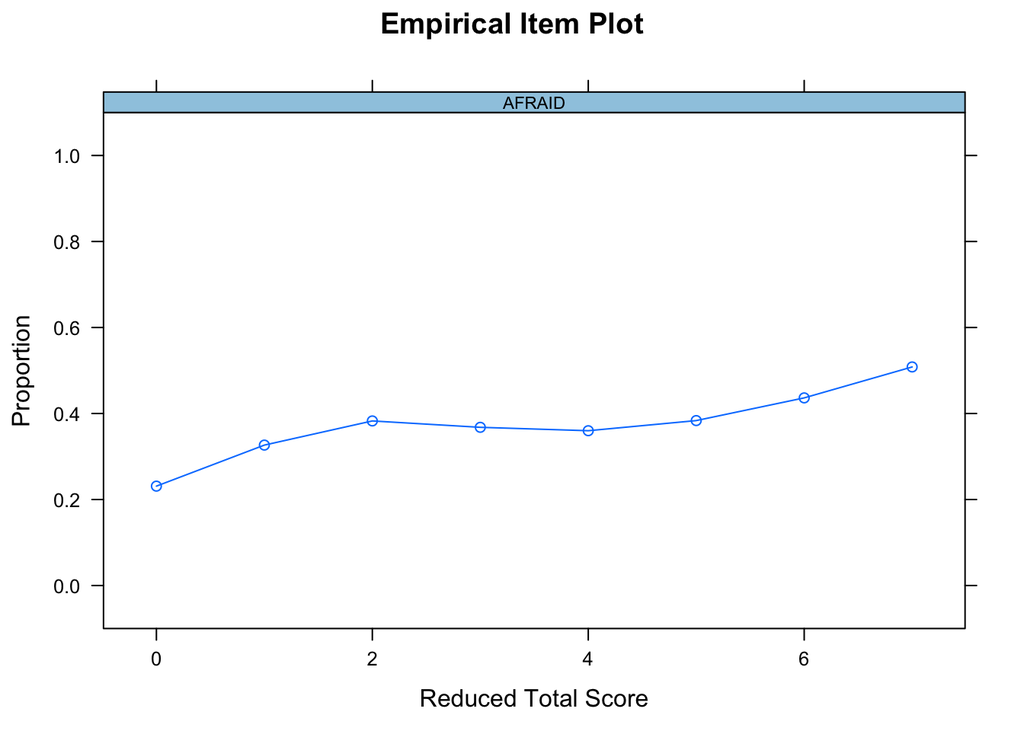

```r
# Look at empirical plots - total scores
library(mirt)
empirical_plot(trolls_models$full_model$X
               ,1)
```

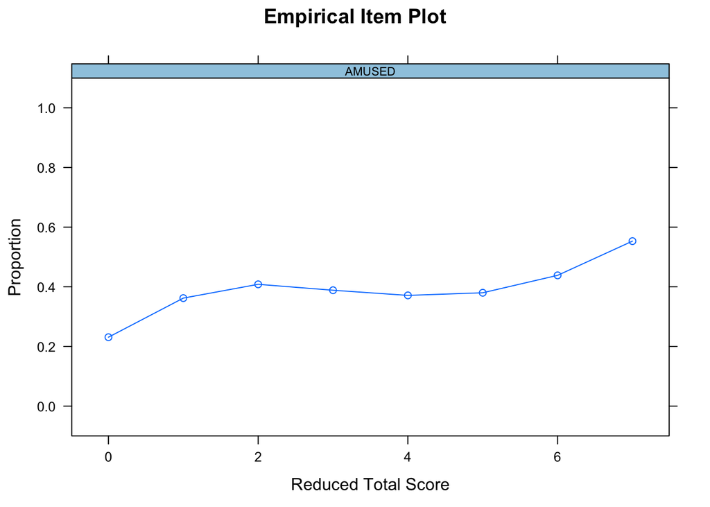

```r
empirical_plot(trolls_models$full_model$X
               ,2)
```

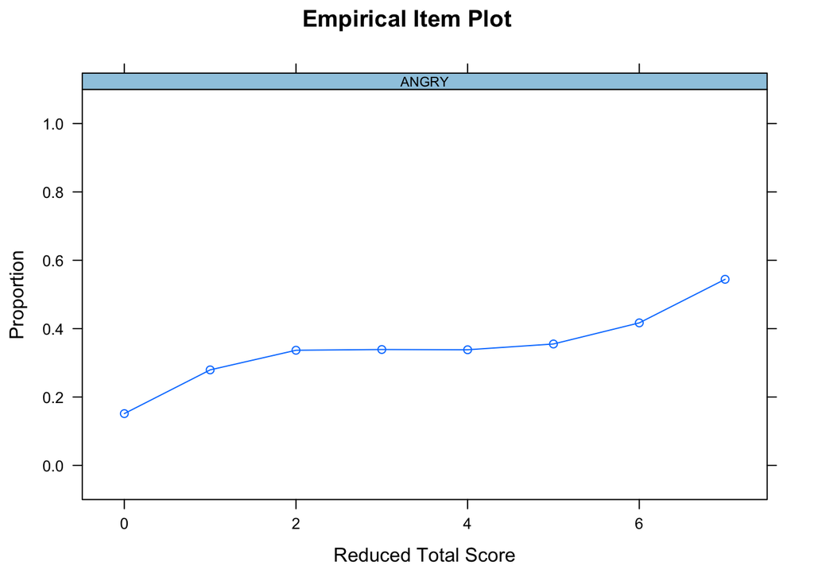

```r
empirical_plot(trolls_models$full_model$X
               ,3)
```

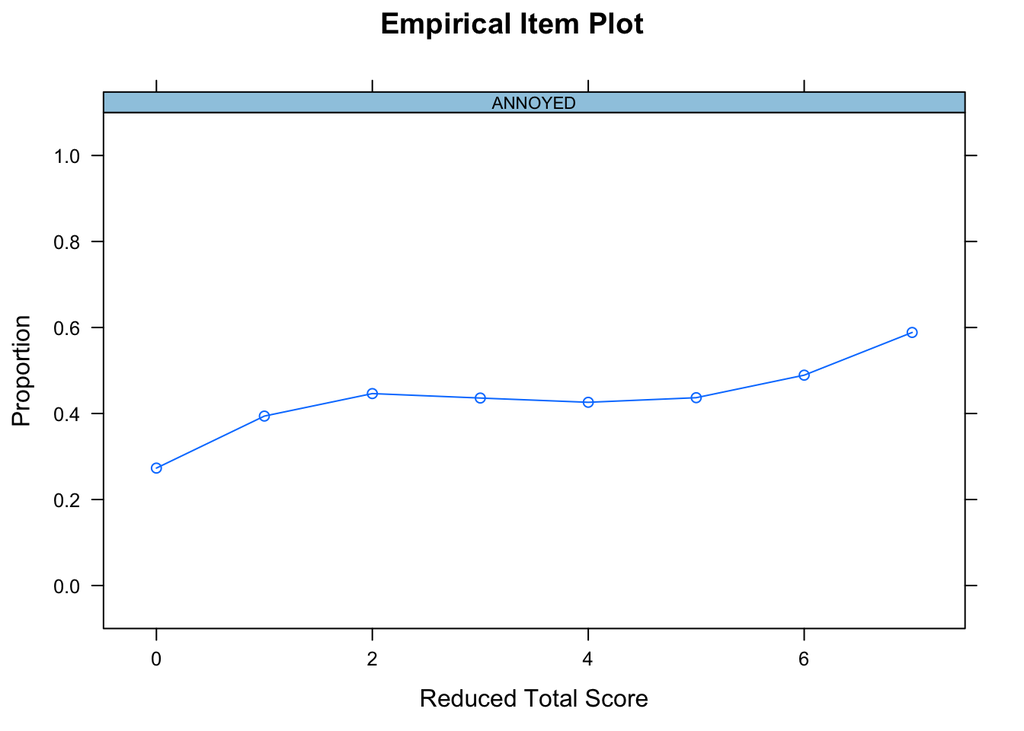

```r
empirical_plot(trolls_models$full_model$X
               ,4)
```

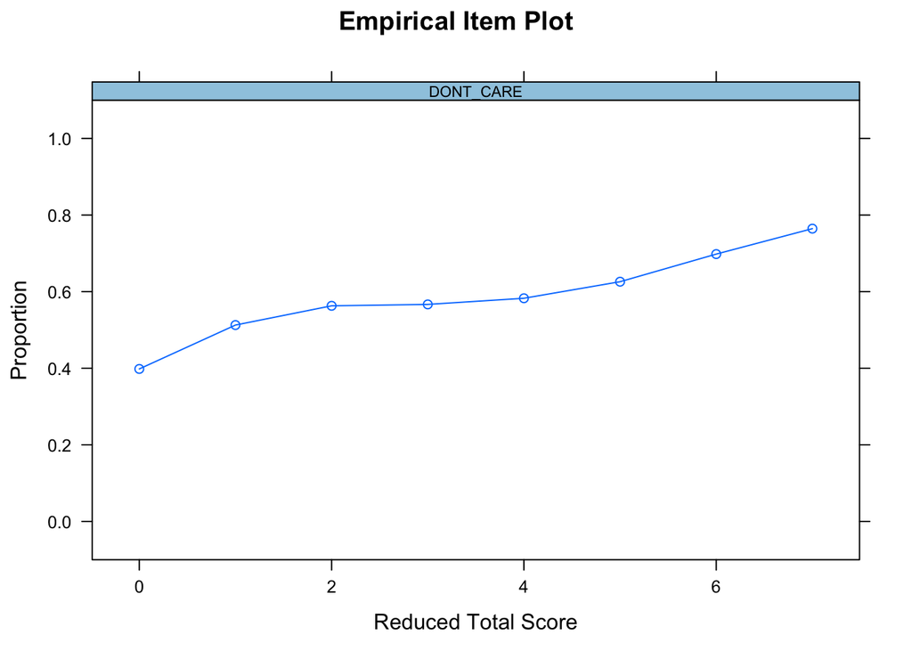

```r
empirical_plot(trolls_models$full_model$X
               ,5)
```

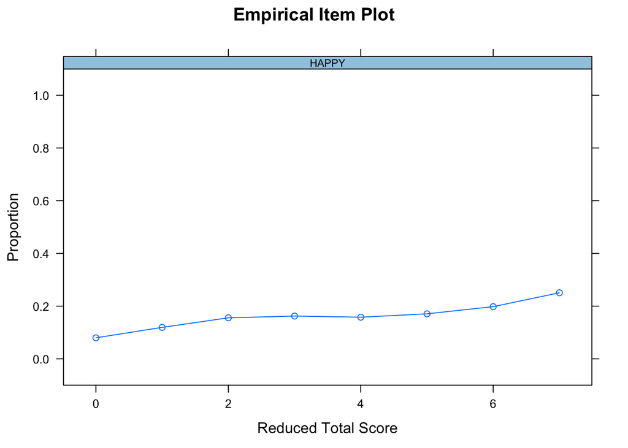

```r
empirical_plot(trolls_models$full_model$X
               ,6)
```

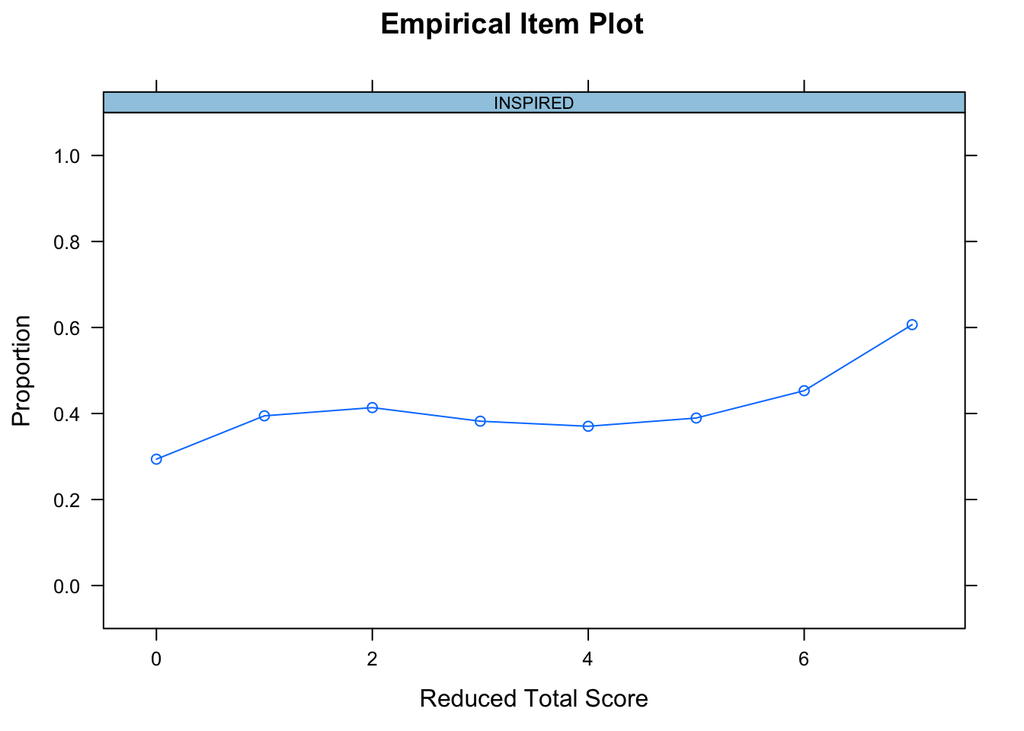

```r
empirical_plot(trolls_models$full_model$X
               ,7)
```

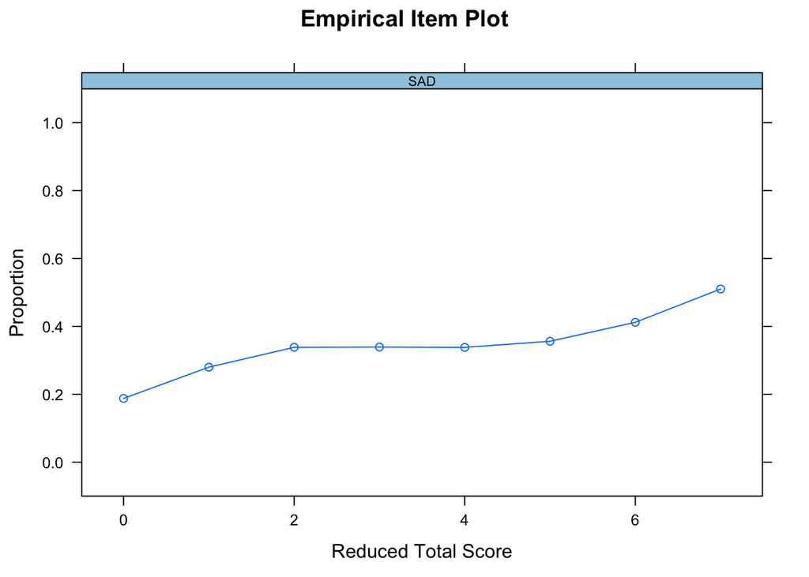

```r
empirical_plot(trolls_models$full_model$X
               ,8)
```

## Item Category Ordering

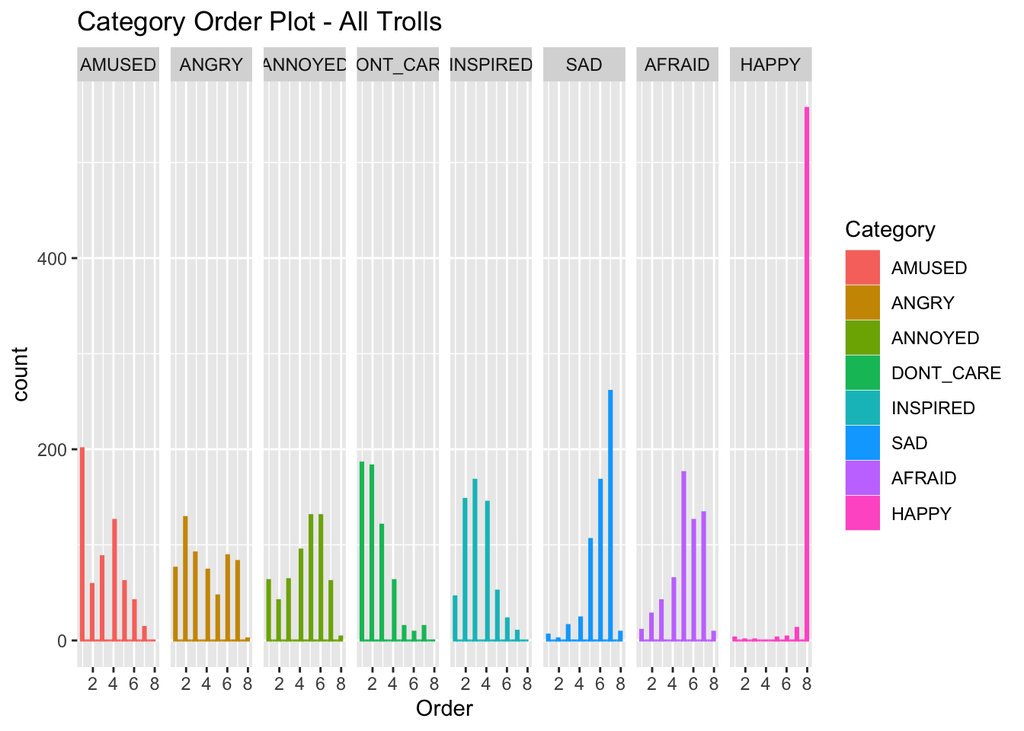

```r
# Item category ordering -----

catplots <- catplot(trolls_models$category_order)
catplotsL <- catplot(trolls_models$category_order[author.small$account_type == "Left",])
catplotsR <- catplot(trolls_models$category_order[author.small$account_type == "Right",])
catplots + ggtitle("Category Order Plot - All Trolls")
```

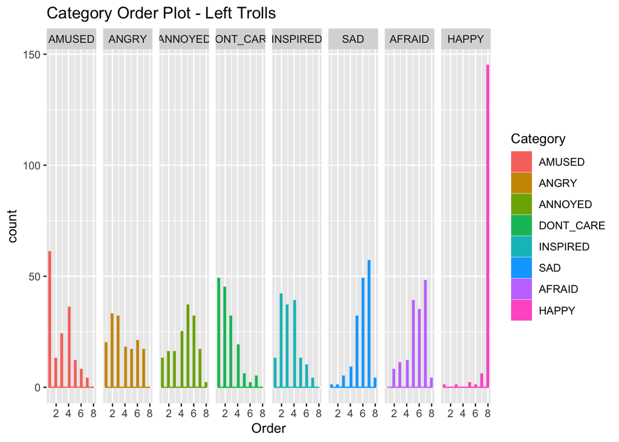

```r
catplotsL + ggtitle("Category Order Plot - Left Trolls")
```

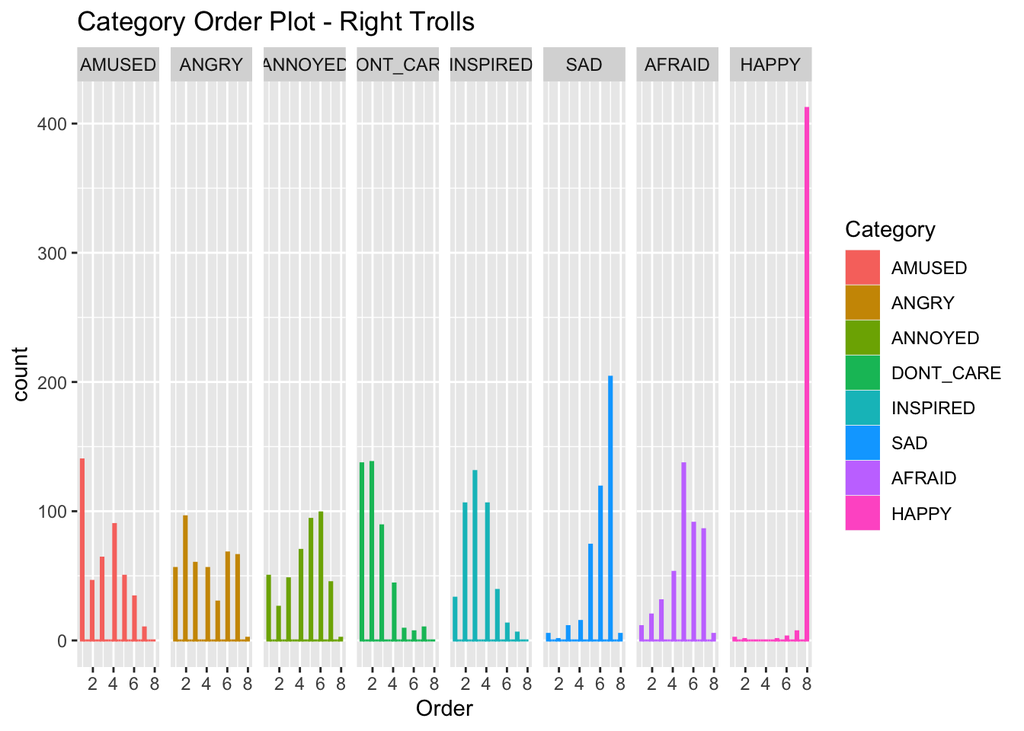

```r
catplotsR  + ggtitle("Category Order Plot - Right Trolls")
```

```r
describe(trolls_models$category_order)
```

```
##           vars   n mean   sd median trimmed  mad min max range  skew kurtosis
## AMUSED       1 592 2.95 1.76      3    2.79 2.97   1   7     6  0.39    -0.97
## ANGRY        2 592 3.84 2.04      3    3.79 2.97   1   8     7  0.23    -1.30
## ANNOYED      3 592 4.44 1.82      5    4.54 1.48   1   8     7 -0.45    -0.76
## DONT_CARE    4 592 2.37 1.38      2    2.17 1.48   1   7     6  1.28     1.74
## INSPIRED     5 592 3.20 1.32      3    3.13 1.48   1   7     6  0.50     0.06
## SAD          6 592 6.07 1.18      6    6.24 1.48   1   8     7 -1.48     2.94
## AFRAID       7 591 5.24 1.52      5    5.39 1.48   1   8     7 -0.68     0.06
## HAPPY        8 582 7.89 0.67      8    8.00 0.00   1   8     7 -8.23    74.25
##             se
## AMUSED    0.07
## ANGRY     0.08
## ANNOYED   0.07
## DONT_CARE 0.06
## INSPIRED  0.05
## SAD       0.05
## AFRAID    0.06
## HAPPY     0.03
```

```r
describe(trolls_models$category_order[author.small$account_type == "Right",])
```

```
##           vars   n mean   sd median trimmed  mad min max range  skew kurtosis
## AMUSED       1 434 3.01 1.77      3    2.86 2.97   1   7     6  0.34    -1.03
## ANGRY        2 434 3.89 2.08      4    3.86 2.97   1   8     7  0.20    -1.36
## ANNOYED      3 434 4.43 1.83      5    4.53 1.48   1   8     7 -0.48    -0.76
## DONT_CARE    4 434 2.33 1.36      2    2.14 1.48   1   7     6  1.32     1.94
## INSPIRED     5 434 3.17 1.27      3    3.11 1.48   1   7     6  0.47     0.12
## SAD          6 434 6.11 1.17      6    6.30 1.48   1   8     7 -1.63     3.55
## AFRAID       7 434 5.14 1.52      5    5.28 1.48   1   8     7 -0.68     0.13
## HAPPY        8 426 7.92 0.61      8    8.00 0.00   1   8     7 -9.44    96.28
##             se
## AMUSED    0.09
## ANGRY     0.10
## ANNOYED   0.09
## DONT_CARE 0.07
## INSPIRED  0.06
## SAD       0.06
## AFRAID    0.07
## HAPPY     0.03
```

```r
describe(trolls_models$category_order[author.small$account_type == "Left",])
```

```
##           vars   n mean   sd median trimmed  mad min max range  skew kurtosis
## AMUSED       1 158 2.78 1.73      3    2.60 2.97   1   7     6  0.51    -0.79
## ANGRY        2 158 3.70 1.93      3    3.62 1.48   1   7     6  0.30    -1.16
## ANNOYED      3 158 4.46 1.81      5    4.54 1.48   1   8     7 -0.37    -0.79
## DONT_CARE    4 158 2.46 1.46      2    2.25 1.48   1   7     6  1.17     1.21
## INSPIRED     5 158 3.27 1.44      3    3.18 1.48   1   7     6  0.53    -0.22
## SAD          6 158 5.94 1.20      6    6.09 1.48   1   8     7 -1.10     1.59
## AFRAID       7 157 5.54 1.49      6    5.70 1.48   2   8     6 -0.72    -0.20
## HAPPY        8 156 7.83 0.79      8    8.00 0.00   1   8     7 -6.23    43.33
##             se
## AMUSED    0.14
## ANGRY     0.15
## ANNOYED   0.14
## DONT_CARE 0.12
## INSPIRED  0.11
## SAD       0.10
## AFRAID    0.12
## HAPPY     0.06
```

Now I do two tests to see if these distributions are different, t-test (mean) and a Kolmogorov-Smirnov Tests (distribution). Both come to the same conclusion: the only one that is different is AFRAID. It is easier for Right trolls. All other categories have similar useage.

```r
dat<- data.frame(
  cbind(trolls_models$category_order,
        group=author.small[["account_type"]]))
aggregate(. ~ group,dat, FUN=mean)
```

```
##   group   AMUSED    ANGRY  ANNOYED DONT_CARE INSPIRED      SAD   AFRAID
## 1  Left 2.767742 3.690323 4.477419  2.445161 3.270968 5.961290 5.522581
## 2 Right 3.030516 3.892019 4.406103  2.328638 3.178404 6.112676 5.136150
##      HAPPY
## 1 7.864516
## 2 7.915493
```

```r
# t tests
ttests<-lapply(colnames(trolls_models$category_order), function(i){
  t.test(trolls_models$category_order[author.small$account_type == "Right",i],
         trolls_models$category_order[author.small$account_type == "Left",i])
})
# pvalues
cat("\n pvalues for t test \n")
```

```
##
##  pvalues for t test
```

```r
sapply(1:length(colnames(trolls_models$category_order)), function(num){
  rbind(colnames(trolls_models$category_order)[num],
        round(ttests[[num]]$p.value,2))
})
```

```
##      [,1]     [,2]    [,3]      [,4]        [,5]       [,6]   [,7]     [,8]
## [1,] "AMUSED" "ANGRY" "ANNOYED" "DONT_CARE" "INSPIRED" "SAD"  "AFRAID" "HAPPY"
## [2,] "0.15"   "0.29"  "0.83"    "0.36"      "0.45"     "0.13" "0"      "0.24"
```

```r
# distribution tests
kstests<-suppressWarnings(lapply(colnames(trolls_models$category_order), function(i){
  ks.test(trolls_models$category_order[author.small$account_type == "Right",i],
          trolls_models$category_order[author.small$account_type == "Left",i])
}))
# pvalues
cat("\n pvalues for KS test \n")
```

```
##
##  pvalues for KS test
```

```r
sapply(1:length(colnames(trolls_models$category_order)), function(num){
  rbind(colnames(trolls_models$category_order)[num],
        round(kstests[[num]]$p.value,2))
})
```

```
##      [,1]     [,2]    [,3]      [,4]        [,5]       [,6]   [,7]     [,8]
## [1,] "AMUSED" "ANGRY" "ANNOYED" "DONT_CARE" "INSPIRED" "SAD"  "AFRAID" "HAPPY"
## [2,] "0.72"   "0.57"  "1"       "0.99"      "0.97"     "0.24" "0.03"   "1"
```

## Mutual Information

First, I ran a quick simulation to determine the minimum amount of mutual information (where higher values = less information). Then, I calculated MI for left and right trolls, and then bootstrapped confidence intervals. Looking at the information from the bootstrapping, the MI is slightly positively biased (approx. +.30).

```r
# Mutual Information -----

# Determine the minimum amount of mutual information possible
min_info<-vector(mode = "numeric")
j<-500
for(j in 1:j){
  n<-400
  ranMi<-matrix(nrow=n, ncol=8)
  for(i in 1:n){
    ranMi[i,] <- sample(1:8, 8,replace = FALSE)}
  min_info[j]<-multiinformation(ranMi)
}
summary(min_info)
```

```
##    Min. 1st Qu.  Median    Mean 3rd Qu.    Max.
##   10.54   10.57   10.58   10.58   10.59   10.62
```

```r
# Calculate mutual information per group

multiinformation(trolls_models$category_order)
```

```
## [1] 6.565666
```

```r
multiinformation(trolls_models$category_order[which(author.small$account_type=="Right"),])
```

```
## [1] 6.629075
```

```r
multiinformation(trolls_models$category_order[which(author.small$account_type=="Left"),])
```

```
## [1] 7.497676
```

```r
# bootstrap CI for mutual information
mi <- function(data, indices) {
  d <- data[indices,] # allows boot to select sample
  mi<- multiinformation(data[indices,])
  return((mi))
}
boot.left <-boot(trolls_models$category_order
                 [which(author.small$account_type=="Left"),],
                 statistic = mi, R=1000)
boot.left
```

```
##
## ORDINARY NONPARAMETRIC BOOTSTRAP
##
##
## Call:
## boot(data = trolls_models$category_order[which(author.small$account_type ==
##     "Left"), ], statistic = mi, R = 1000)
##
##
## Bootstrap Statistics :
##     original    bias    std. error
## t1* 7.497676 0.3214887    0.208247
```

```r
bci.left<-boot.ci(boot.left, conf = .95, type = "norm")


boot.right <-boot(trolls_models$category_order
                  [which(author.small$account_type=="Right"),],
                  statistic = mi, R=1000)
boot.right
```

```
##
## ORDINARY NONPARAMETRIC BOOTSTRAP
##
##
## Call:
## boot(data = trolls_models$category_order[which(author.small$account_type ==
##     "Right"), ], statistic = mi, R = 1000)
##
##
## Bootstrap Statistics :
##     original    bias    std. error
## t1* 6.629075 0.2968026    0.108623
```

```r
bci.right<-boot.ci(boot.right, conf = .95, type = "norm")



# plot

plotdat2 <- data.frame(
  MI = c(multiinformation(trolls_models$category_order[which(author.small$account_type=="Right"),]),
             multiinformation(trolls_models$category_order[which(author.small$account_type=="Left"),])),
  ci.low =  c(bci.right$normal[2],
             bci.left$normal[2]),
  ci.high =  c(bci.right$normal[3],
             bci.left$normal[3]),
  Group = c("Right", "Left")
)
plotdat2
```

```
##         MI   ci.low  ci.high Group
## 1 6.629075 6.119375 6.545169 Right
## 2 7.497676 6.768031 7.584344  Left
```

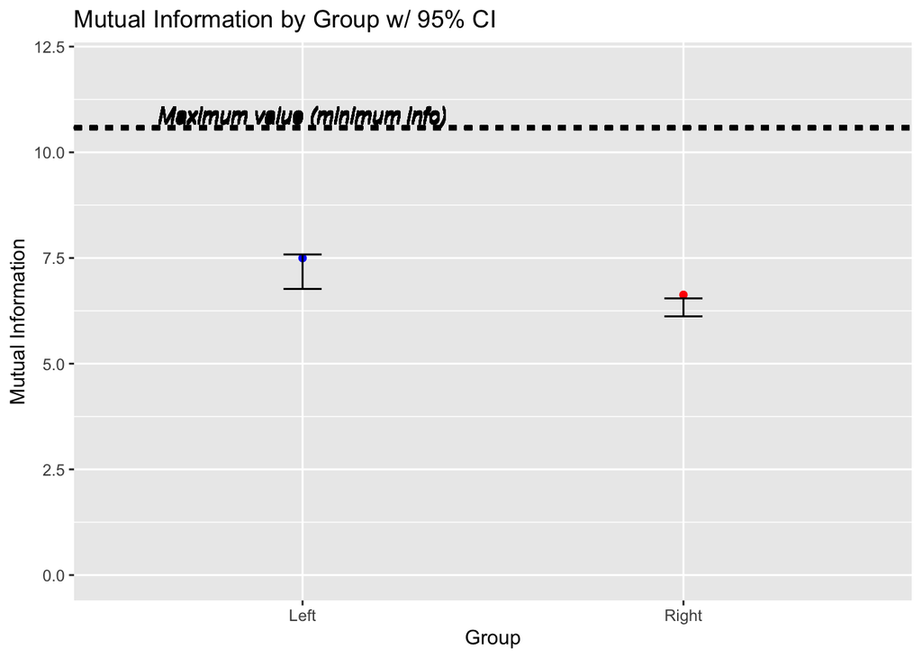

```r
ggplot(data = plotdat2) + geom_point(aes(x=Group, y=MI), color = c("Red", "Blue")) +
  geom_hline(yintercept = min_info, linetype="dashed") +
  geom_errorbar(aes(ymin=ci.low, ymax=ci.high, x = Group), colour="black", width=.1) +
  ggtitle("Mutual Information by Group w/ 95% CI") + ylim(0,12) +
  annotate("text", label="Maximum value (minimum info)",
           x=1, y=min_info+.3,
           size=4, fontface="italic") +
  ylab("Mutual Information")
```

## Emodiversity

Quick look at the “emodiversity” of the trolls (Benson, 2017). This is done using the gini coefficient. Note that the coefficient fails (is NA) when the whole vector is zeros.

I calculated it per tweet, and within authors (suming up emotion scores, and then calculating it), and average tweets per author (calculating it per tweet, then averaging within an author, all NA’s removed). For each grouping, I calculated it with the raw emotion scores and the dichotomized emotion scores.

```r
# Diversity -----
# Gini Coefficient
# FYI, it fails when all responses are zero, row gets NA

# Gini by tweet
gini_trolls_tweets <- data.frame(full = apply(trolls_scored[,c(-1,-2)],1,reldist::gini),
                                 dich = apply(trolls_models$full_model$X,1,reldist::gini),
                                 group = trolls$account_type)
# Gini by author
gini_trolls_author <-
  data.frame(
    full = sapply(unique(trolls$author), function(group) {
      x <- trolls_scored[trolls$author == group, ]
      if(ncol(x) != 10){NA}else{
        reldist::gini(colSums(x[, c("AFRAID",
                                    "AMUSED",
                                    "ANGRY",
                                    "ANNOYED",
                                    "DONT_CARE",
                                    "HAPPY",
                                    "INSPIRED",
                                    "SAD")]))}
    }),

    dich = sapply(unique(trolls$author), function(group) {
      x <- trolls_models$full_model$X[trolls$author == group, ]
      if(length(x) <= 8){z<-NA}else{
        reldist::gini(colSums(x[, c("AFRAID",
                                    "AMUSED",
                                    "ANGRY",
                                    "ANNOYED",
                                    "DONT_CARE",
                                    "HAPPY",
                                    "INSPIRED",
                                    "SAD")]))}
    }),
    group = unique(trolls[trolls$author %in% unique(trolls$author),c("author","account_type")])$account_type,
    author = unique(trolls$author)
  )

# Average gini by tweet within authors
gini_trolls_tweets_average <- do.call(rbind, lapply(unique(trolls$author), function(auth){
  x <- gini_trolls_tweets[trolls$author == auth, ]
  averages <- data.frame(
    full = mean(na.omit(x$full)),
    dich = mean(na.omit(x$dich)),
    author = as.character(auth),
    group = x$group[1],
    stringsAsFactors = FALSE
  )
  averages
}))
```

Now I look at the results.

Within grouping (tweet, author, tweet/author), the correlation between the full and dichotomized gini was high, but not perfect.

- Tweet = .65
- Author = .56
- Average Tweet/author = .72

It’s probably best to use the full, not dichotomized data, because it’s more information. The only downside is the scaling of the variables (they may not be the same). So that’s what I will report below.

All three types show sig. differences between the groups in the same direction. Left trolls have higher emodiversity (gini coefficient) than the right trolls.

```r
# .7 correlation between the two per tweet, less NA's with full (not dich)
cor(na.omit(gini_trolls_tweets[c("full","dich")]))
```

```
##           full      dich
## full 1.0000000 0.6548102
## dich 0.6548102 1.0000000
```

```r
cor(na.omit(gini_trolls_author[c("full","dich")]))
```

```
##           full      dich
## full 1.0000000 0.5645858
## dich 0.5645858 1.0000000
```

```r
cor(na.omit(gini_trolls_tweets_average[c("full","dich")]))
```

```
##           full      dich
## full 1.0000000 0.7235635
## dich 0.7235635 1.0000000
```

```r
# aggregate(full ~ group, gini_trolls_tweets, FUN=median)
# aggregate(full ~ group, gini_trolls_author, FUN=median)
# aggregate(full ~ group, gini_trolls_tweets_average, FUN=median)

t.test(full ~ group, gini_trolls_tweets)
```

```
##
##  Welch Two Sample t-test
##
## data:  full by group
## t = 60.819, df = 103160, p-value < 2.2e-16
## alternative hypothesis: true difference in means is not equal to 0
## 95 percent confidence interval:
##  0.03240430 0.03456239
## sample estimates:
##  mean in group Left mean in group Right
##           0.6337317           0.6002483
```

```r
t.test(full ~ group, gini_trolls_author)
```

```
##
##  Welch Two Sample t-test
##
## data:  full by group
## t = 7.2049, df = 412.86, p-value = 2.778e-12
## alternative hypothesis: true difference in means is not equal to 0
## 95 percent confidence interval:
##  0.03181777 0.05569353
## sample estimates:
##  mean in group Left mean in group Right
##           0.4610235           0.4172679
```

```r
t.test(full ~ group, gini_trolls_tweets_average)
```

```
##
##  Welch Two Sample t-test
##
## data:  full by group
## t = 3.0645, df = 390.56, p-value = 0.002332
## alternative hypothesis: true difference in means is not equal to 0
## 95 percent confidence interval:
##  0.004865574 0.022282564
## sample estimates:
##  mean in group Left mean in group Right
##           0.6430943           0.6295202
```

## Notes

- All Right/Left troll tweets are included in the full Rasch model. Only tweets belonging to accounts with > 29 tweets are included in the individual model accounts.
- I removed manual retweets/reposts. Should I consider leaving them in? On one hand, we do not know who “wrote” them. They also may be duplicated between themselves - that is, they are retweeting each other. On the other hand, they are a part of the accounts’ overall “voices.”"